# End-to-end system identification: a Symbolic Math model

This example identifies the parameters of an epidemic model written as a system of differential equations with Symbolic Math Toolbox, and asks the same question its user-defined companion asks: once the model fits, can the parameters actually be recovered?

Here the answer depends on when you stopped collecting data, which makes it a concrete demonstration that identifiability is a property of the experiment and not only of the model.

A Python notebook version of this example runs the same computation with the same section numbering, so the two can be read side by side.

## The model

The classical SIR system for a closed population of $N=1000$:

$\frac{dS}{dt}=-\beta\frac{SI}{N},\qquad \frac{dI}{dt}=\beta\frac{SI}{N}-\gamma I,\qquad \frac{dR}{dt}=\gamma I$

Two factors are to be identified:

- β — transmission rate (1/day)
- γ — recovery rate (1/day)

Their ratio is the basic reproduction number $R_0=\beta/\gamma$, the quantity an epidemiologist actually wants. Only the infected compartment $I(t)$ is observed, and the initial conditions are known: one infected individual in an otherwise susceptible population.

## 1. Preparing the environment

The system is declared with syms and handed straight to gsua_dataprep, which generates the simulation code and returns the summary table.

```matlab
syms S(t) I(t) R(t) beta gamma
N = 1000;                                  % closed population
odes = [diff(S) == -beta*S*I/N             % susceptible
        diff(I) ==  beta*S*I/N - gamma*I   % infected  (this is what we observe)
        diff(R) ==  gamma*I];              % recovered
vars = [S I R];                            % state order -- fixes the factor order below
```

For a symbolic model the factor vector is the initial conditions of the states first, in the order given by vars, followed by the model parameters. Giving a factor a degenerate range fixes it and drops it from the table, so the five entries below leave only β and γ free.

```matlab
% Rows: S0, I0, R0 (all known -> degenerate), then beta, gamma (to estimate).
% 'output',2 declares that the SECOND state, I(t), is the measured one.
[T,~] = gsua_dataprep(odes, vars, [0 80], 'sirEpidemicModel', ...
    'range', [999 999      % S0  susceptible at t=0
              1   1        % I0  infected at t=0
              0   0        % R0  recovered at t=0
              0.15 0.9     % beta
              0.02 0.4], 'output', 2);
```

Setting environment to work with symbolic Matlab Introduce ranges in the following order:

ans =

```matlab
T
```

T = 2×2 table

[output not shown]

## 2. Synthetic data

The true epidemic uses $\beta=0.35$ and $\gamma=0.10$, so $R_0=3.5$. Case counts are noisier when they are larger, so the measurements carry Poisson-like noise whose spread grows with the count.

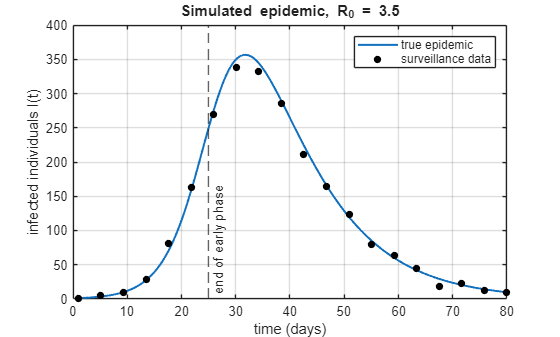

```matlab
rng(3,'twister')                           % fix the noise draw so the page reproduces
truth = [0.35; 0.10];                      % beta, gamma -- the values to recover
T.Nominal = truth;
xfull = linspace(1, 80, 20);               % 80 days of surveillance, 20 reports
% Trailing false,false,false suppresses gsua_eval's diagnostic plot and progress print.
cleanFull = gsua_eval(truth, T, xfull, [], false, false, false);
yfull = cleanFull + sqrt(max(cleanFull,1)).*randn(size(cleanFull));
tdense = linspace(1, 80, 300);             % dense grid, for drawing curves only
plot(tdense, gsua_eval(truth, T, tdense, [], false, false, false), 'LineWidth', 1.5)
hold on
plot(xfull, yfull, 'ko', 'MarkerFaceColor', 'k', 'MarkerSize', 5)
xline(25, '--', 'end of early phase', 'LabelVerticalAlignment', 'bottom')
hold off
xlabel('time (days)')
ylabel('infected individuals I(t)')
legend('true epidemic','surveillance data','Location','northeast')
title('Simulated epidemic, R_0 = 3.5')
grid on
```